# TALLER EVALUADO ANÁLISIS DESCRIPTIVO E INFERENCIAL

# Analisis

## categoria edad ———————————————————-

```r
universo_4 <- datos[c(7,8,12,13)]

pregunta_freq_uso_2019 <-  datos %>%
         group_by(edad_n) %>%
         count(Uso2019) %>%
         filter(Uso2019 !=0 )



pregunta_freq_UsoMayo <-  datos %>%
  group_by(edad_n) %>%
  count(UsoMayo) %>%
  filter( UsoMayo !=0)



unidos <-  full_join(pregunta_freq_uso_2019,pregunta_freq_UsoMayo,by="edad_n")


pregunta_monto_MontoAcum <-   datos[c(7,8,12,13)] %>%
                          group_by(edad_n)  %>%
                          summarise(MontoAcum = sum(MontoAcum),MontoMayo  = sum(MontoMayo )) %>%
                           filter(MontoAcum !=0, MontoMayo !=0 )
pregunta_monto_mean <-   datos[c(7,8,12)] %>%
  group_by(edad_n)  %>%
  summarise(MontoAcum = mean(MontoAcum),MontoMayo  = mean(MontoMayo )) %>%
  filter(MontoAcum !=0, MontoMayo !=0 )
pregunta_monto_mean =  rename(pregunta_monto_mean, "Categoria"  = edad_n , "Mean Acum 2019 Enero - Mayo"=MontoAcum ,"Mean Mayo"= MontoMayo)


unidos_2 <-  full_join(unidos,pregunta_monto_MontoAcum,by="edad_n")

final <- unidos_2[c(1,3,6,5,7)]

final_categoria_edad =  rename(final, "Categoria"  = edad_n , "Freq Uso enero a Mayo 2019" = n.x, "Monto Acum 2019 Enero - Mayo"=MontoAcum , "Freq Mayo"=  n.y ,"Monto Mayo"= MontoMayo)

unidos_edad <-  full_join(pregunta_monto_mean,final_categoria_edad,by="Categoria")

unidos_edad <-   unidos_edad[c(1,4,5,2,6,7,3)]


kableExtra::scroll_box(knitr::kable(head(unidos_edad)), height = 3, fixed_thead = list(enabled = T/F, background = "anycolor"))
```

| Categoria | Freq Uso enero a Mayo 2019 | Monto Acum 2019 Enero - Mayo | Mean Acum 2019 Enero - Mayo | Freq Mayo | Monto Mayo | Mean Mayo |
| --- | --- | --- | --- | --- | --- | --- |
| ENTRE 36 A 54 | 144 | 179868 | 768.6667 | 96 | 44259 | 189.14103 |
| MAYORES O IGUAL 55 | 55 | 60492 | 458.2727 | 31 | 12591 | 95.38636 |
| MENORES O IGUAL A 35 | 63 | 76491 | 910.6071 | 41 | 18633 | 221.82143 |

```r
# analsiis  de categoria edaddes entre enero y mayo 2019
#se puede apreciar que la frecuencia la mayor frecuencia de uso es entre 36 a 53 años. pero los montos promedios se puede ver que los menores de 35 años o = a 35 tiene una mayor gastos  vs las demas edades.

#analisis de castegoria por edad en mayo
#se puede apreciar que nuemnanete la frecuencia de uso esta entre 36 a 54 años, ademas se repite el promedio mayor de gasto en la edad de menores o ifguales a 35 años.
```

## categoria por region —————————————————-

```r
pregunta_freq_uso_2019_region <-  datos %>%
  group_by(reg_n) %>%
  count(Uso2019) %>%
  filter(Uso2019 !=0 )


pregunta_freq_UsoMayo_region <-  datos %>%
  group_by(reg_n) %>%
  count(UsoMayo) %>%
  filter( UsoMayo !=0)


unidos_reg <-  full_join(pregunta_freq_uso_2019_region,pregunta_freq_UsoMayo_region,by="reg_n")

pregunta_monto_MontoAcum_reg_n <-   datos %>%
  group_by(reg_n)  %>%
  summarise(MontoAcum = sum(MontoAcum),MontoMayo  = sum(MontoMayo )) %>%
  filter(MontoAcum !=0, MontoMayo !=0 )
pregunta_mean_reg_n <-   datos %>%
  group_by(reg_n)  %>%
  summarise(MontoAcum = mean(MontoAcum),MontoMayo  = mean(MontoMayo )) %>%
  filter(MontoAcum !=0, MontoMayo !=0 )
pregunta_mean_reg_n =  rename(pregunta_mean_reg_n, "Region"  = reg_n , "Mean Acum 2019 Enero - Mayo"=MontoAcum  ,"Mean Mayo"= MontoMayo)

datos_regiones <-  full_join(unidos_reg,pregunta_monto_MontoAcum_reg_n,by="reg_n")



final_region <- datos_regiones[c(1,3,6,5,7)]


final_region =  rename(final_region, "Region"  = reg_n , "Freq Uso enero a Mayo 2019" = n.x, "Monto Acum 2019 Enero - Mayo"=MontoAcum , "Freq Mayo"=  n.y ,"Monto Mayo"= MontoMayo)

unidos_reg_resumen <-  full_join(final_region,pregunta_mean_reg_n,by="Region")

tabla_resumen_region <- unidos_reg_resumen[c(1,2,3,6,4,5,7)]




kableExtra::scroll_box(knitr::kable(head(tabla_resumen_region)), height = 3, fixed_thead = list(enabled = T/F, background = "anycolor"))
```

| Region | Freq Uso enero a Mayo 2019 | Monto Acum 2019 Enero - Mayo | Mean Acum 2019 Enero - Mayo | Freq Mayo | Monto Mayo | Mean Mayo |
| --- | --- | --- | --- | --- | --- | --- |
| Otras | 142 | 171493 | 708.6488 | 86 | 39139 | 161.7314 |
| RM | 120 | 145358 | 698.8365 | 82 | 36344 | 174.7308 |

```r
#analisi acumulado de regiones entre enero a mayo 2019
#se puede apreciar que en otras regiones se tiene una mayor frequiencia de uso de la tarjeta y ademas tiene un promedio mayor de monto 709 OTRAS. vs 699 de RM.

#analisis de regiones en mayo
# se puede apreciar que nuevamente la tarjtea tyiene mayor frequencia de uso en otras regiones, por otro lado el monto promedio en mayo es mayor en la region metropolitana  con 175 vs 162 de otras.
```

## categoria por sexo —————————————————-

```r
uso_por_Sexo_mean <-  datos[c(9,7,8)] %>%
  group_by(sex_n )  %>%
  summarise( MontoAcum = mean(MontoAcum),MontoMayo  = mean(MontoMayo)) %>%
  filter(MontoAcum !=0, MontoMayo !=0 )
final_sexo_mean =  rename(uso_por_Sexo_mean, "Mean MontoAcum " = MontoAcum , "Mean MontoMayo"=MontoMayo)

uso_por_Sexo <-  datos[c(9,5,6,7,8)] %>%
               group_by(sex_n )  %>%
               summarise(Uso2019  = sum(Uso2019 ),UsoMayo  = sum(UsoMayo ),MontoAcum = sum(MontoAcum),MontoMayo  = sum(MontoMayo)) %>%
               filter(MontoAcum !=0, MontoMayo !=0,Uso2019!=0,UsoMayo!=0 )
final_sexo =  rename(uso_por_Sexo, "Freq Uso enero a Mayo 2019 genero" = Uso2019 , "Freq en  Mayo por genero"=UsoMayo , "Monto Mayo"=  MontoAcum ,"Monto Acum 2019 Enero - Mayo"= MontoMayo)


unidos_sex_resumen <-  full_join(final_sexo_mean,final_sexo,by="sex_n")

tabla_sex_resumen <- unidos_sex_resumen[c(1, 4,7,2,5,6,3)]



tabla_sex_resumen <-  data.frame(tabla_sex_resumen)



kableExtra::scroll_box(knitr::kable(head(tabla_sex_resumen)), height = 3, fixed_thead = list(enabled = T/F, background = "anycolor"))
```

| sex_n | Freq.Uso.enero.a.Mayo.2019.genero | Monto.Acum.2019.Enero…Mayo | Mean.MontoAcum. | Freq.en..Mayo.por.genero | Monto.Mayo | Mean.MontoMayo |
| --- | --- | --- | --- | --- | --- | --- |
| Femenino | 112 | 31808 | 745.9348 | 73 | 137252 | 172.8696 |
| Masculino | 150 | 43675 | 675.1842 | 95 | 179599 | 164.1917 |

```r
# analisis monto acumulado
#se puede apreciar que sexo masculino tiene una mayor frecuencia de uso de tarjeta entre entero a mayo 2019.
#ademas se puede apreciar que las mujeres en promedio tiende a gastar mas dinero.

#analisis solo mayo
#nuevamente se puede apreciar que los hombre usan mas la tarjeta en mayo.
# y en promedio las mujeres gastan mas que los hombre.
```

## RM o Otras ~ Edad~ sexo —————————————————-

```r
#Otras


perfectiva_femenino <-
datos %>%
group_by( reg_n,edad_n,sex_n) %>%
summarise(MontoAcum_mean  = mean(MontoAcum ),MontoMayo_mean  = mean(MontoMayo ),Uso2019  = sum(Uso2019 ),MontoAcum  = sum(MontoAcum ),UsoMayo  = sum(UsoMayo ),MontoMayo  = sum(MontoMayo ))  %>%
filter( reg_n=="Otras" , sex_n =="Femenino")
### resumen en tabla de la region metropolitana masculino y sus rango de edad
```

### Tabla de resumen Otras regiones sexo femenino.

```r
kableExtra::scroll_box(knitr::kable(head(perfectiva_femenino)), height = 3, fixed_thead = list(enabled = T/F, background = "anycolor"))
```

| reg_n | edad_n | sex_n | MontoAcum_mean | MontoMayo_mean | Uso2019 | MontoAcum | UsoMayo | MontoMayo |
| --- | --- | --- | --- | --- | --- | --- | --- | --- |
| Otras | ENTRE 36 A 54 | Femenino | 768.5490 | 202.4902 | 32 | 39196 | 22 | 10327 |
| Otras | MAYORES O IGUAL 55 | Femenino | 650.9600 | 121.6400 | 14 | 16274 | 7 | 3041 |
| Otras | MENORES O IGUAL A 35 | Femenino | 934.9091 | 187.6364 | 17 | 20568 | 10 | 4128 |

```r
perfectiva_masculino <-
  datos %>%
  group_by( reg_n,edad_n,sex_n) %>%
  summarise(MontoAcum_mean  = mean(MontoAcum ),MontoMayo_mean  = mean(MontoMayo ),Uso2019  = sum(Uso2019 ),MontoAcum  = sum(MontoAcum ),UsoMayo  = sum(UsoMayo ),MontoMayo  = sum(MontoMayo ))  %>%
filter(reg_n=="Otras",sex_n =="Masculino" )
```

### Tabla de resumen Otras regiones sexo Masculino

```r
kableExtra::scroll_box(knitr::kable(head(perfectiva_masculino)), height = 3, fixed_thead = list(enabled = T/F, background = "anycolor"))
```

| reg_n | edad_n | sex_n | MontoAcum_mean | MontoMayo_mean | Uso2019 | MontoAcum | UsoMayo | MontoMayo |
| --- | --- | --- | --- | --- | --- | --- | --- | --- |
| Otras | ENTRE 36 A 54 | Masculino | 622.6860 | 138.0465 | 45 | 53551 | 26 | 11872 |
| Otras | MAYORES O IGUAL 55 | Masculino | 549.3438 | 108.7188 | 16 | 17579 | 9 | 3479 |
| Otras | MENORES O IGUAL A 35 | Masculino | 935.5769 | 242.0000 | 18 | 24325 | 12 | 6292 |

## Informacion de otras

### Uso en mayo en “Otras regiones” y Femenino

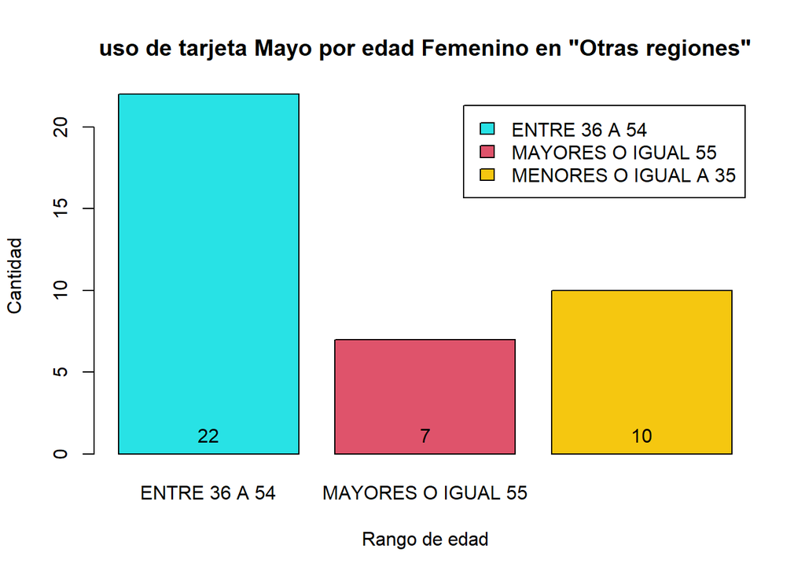

```r
#frecuencia
# uso de tarjeta UsoMayo por edad segun la region
hist_1 <-
barplot(perfectiva_femenino$UsoMayo,
        xlab="Rango de edad",
legend.text=perfectiva_femenino$edad_n,
col=c('5','2',55),
main='uso de tarjeta Mayo por edad Femenino en "Otras regiones"' ,
ylab='Cantidad',

names.arg=perfectiva_femenino$edad_n)

text(hist_1,
0,
round(perfectiva_femenino$UsoMayo, 3),cex=1,pos=3)
```

Tiene mayor cantidad de uso entre la edad de 36 a 54, 22 veces en mayo 2019.

### Uso en mayo en “Otras regiones” y Masculino

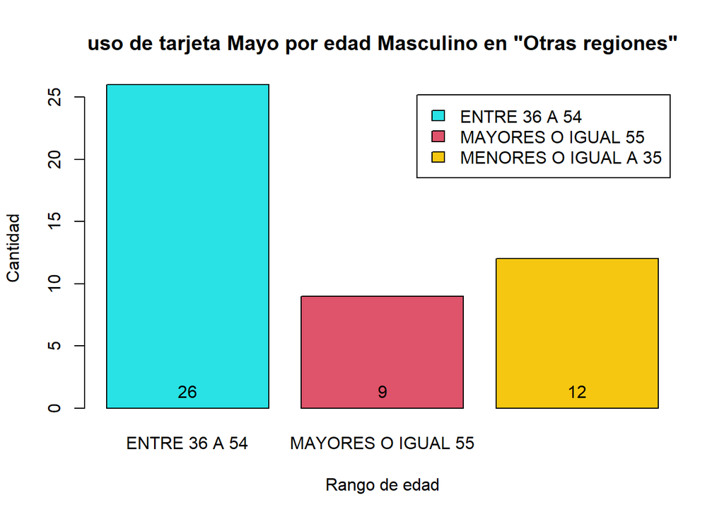

```r
hist_2 <-
barplot(perfectiva_masculino$UsoMayo,
xlab="Rango de edad",
legend.text=perfectiva_masculino$edad_n,
col=c('5','2',55),
          main='uso de tarjeta Mayo por edad Masculino en "Otras regiones"' ,
ylab='Cantidad',

names.arg=perfectiva_masculino$edad_n)

text(hist_1,
0,
round(perfectiva_masculino$UsoMayo, 3),cex=1,pos=3)
```

Tiene mayor cantidad de uso entre la edad de 36 a 54, 26 veces en mayo 2019.

### Uso de tarjeta Enero a mayo 2019 por edad Femenino en “Otras regiones”

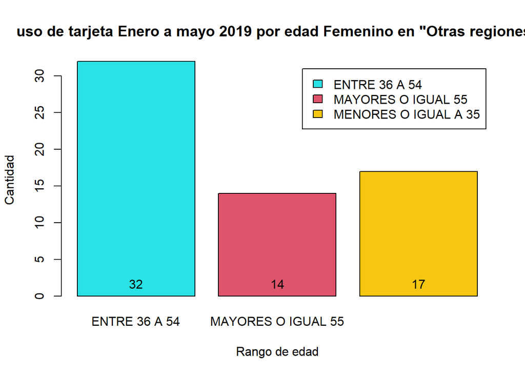

```r
#uso de tarjeta Uso2019 por edad segun la region
hist_1 <-
  barplot(perfectiva_femenino$Uso2019,
          xlab="Rango de edad",
          legend.text=perfectiva_femenino$edad_n,
          col=c('5','2',55),
          main='uso de tarjeta Enero a mayo 2019 por edad Femenino en "Otras regiones"' ,
          ylab='Cantidad',

          names.arg=perfectiva_femenino$edad_n)

text(hist_1,
     0,
     round(perfectiva_femenino$Uso2019, 3),cex=1,pos=3)
```

Tiene mayor cantidad de uso entre la edad de 36 a 54, 32 veces en enero a mayo 2019.

### Uso de tarjeta Enero a mayo 2019 por edad Masculino en “Otras regiones”

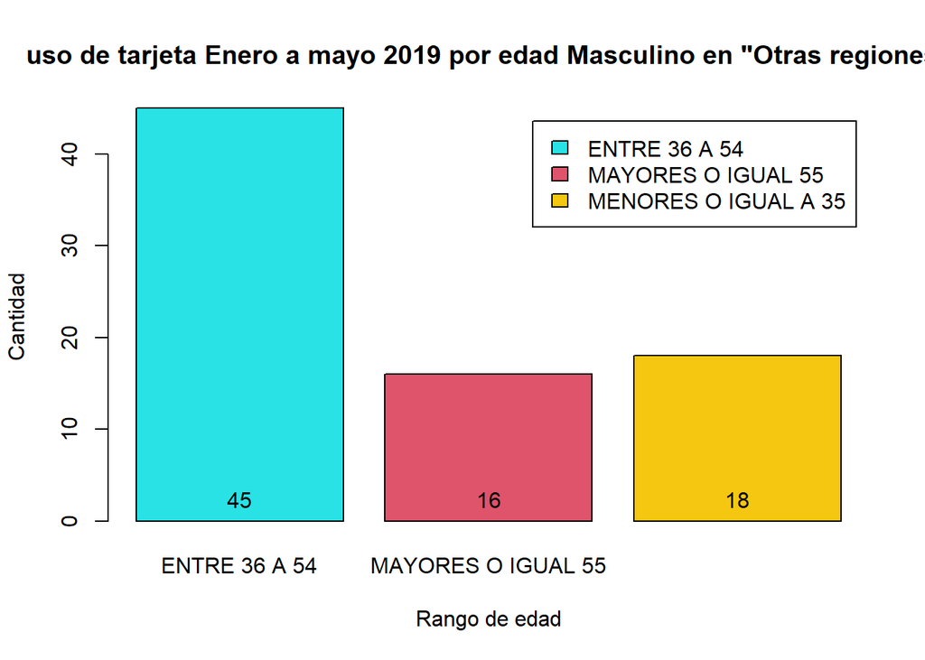

```r
hist_2 <-
  barplot(perfectiva_masculino$Uso2019,
          xlab="Rango de edad",
          legend.text=perfectiva_masculino$edad_n,
          col=c('5','2',55),
          main='uso de tarjeta Enero a mayo 2019 por edad Masculino en "Otras regiones"' ,
          ylab='Cantidad',

          names.arg=perfectiva_masculino$edad_n)

text(hist_1,
     0,
     round(perfectiva_masculino$Uso2019, 3),cex=1,pos=3)
```

Tiene mayor cantidad de uso entre la edad de 36 a 54, 45 veces en enero a mayo 2019.

### Media Monto en mayo en “Otras regiones” y Femenino

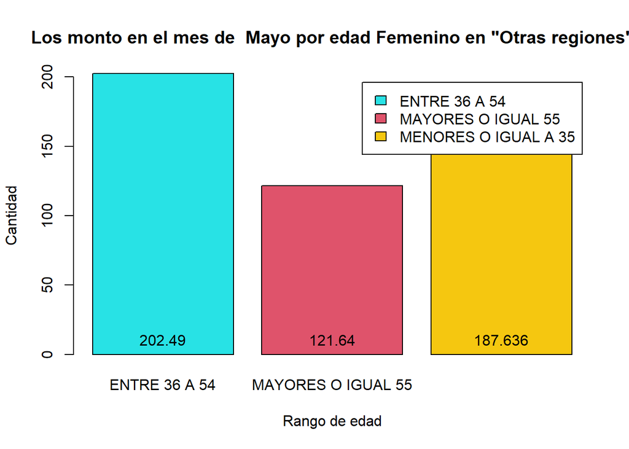

```r
#frecuencia
# uso de tarjeta UsoMayo por edad segun la region
hist_1 <-
barplot(perfectiva_femenino$MontoMayo_mean,
        xlab="Rango de edad",
legend.text=perfectiva_femenino$edad_n,
col=c('5','2',55),
main='Los monto en el mes de  Mayo por edad Femenino en "Otras regiones"' ,
ylab='Cantidad',

names.arg=perfectiva_femenino$edad_n)

text(hist_1,
0,
round(perfectiva_femenino$MontoMayo_mean, 3),cex=1,pos=3)
```

Tiene un mayor media de 202.4 entre la edades de 36 a 54 de los montos las femenina.

### Media Monto en mayo en “Otras regiones” y Masculino

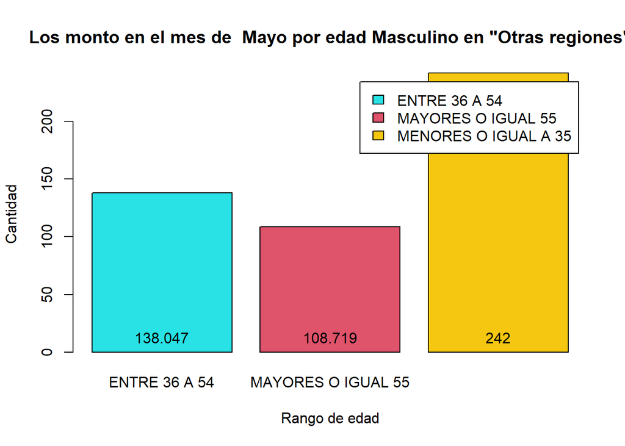

```r
#frecuencia
# uso de tarjeta UsoMayo por edad segun la region
hist_1 <-
barplot(perfectiva_masculino$MontoMayo_mean,
        xlab="Rango de edad",
legend.text=perfectiva_masculino$edad_n,
col=c('5','2',55),
main='Los monto en el mes de  Mayo por edad Masculino en "Otras regiones"' ,
ylab='Cantidad',

names.arg=perfectiva_masculino$edad_n)

text(hist_1,
0,
round(perfectiva_masculino$MontoMayo_mean, 3),cex=1,pos=3)
```

Tiene un mayor media de 242 entre los menores o igual a 365 de los montos las Masculino

### Media de los montos en Enero a mayo 2019 por edad Masculino en “Otras regiones”

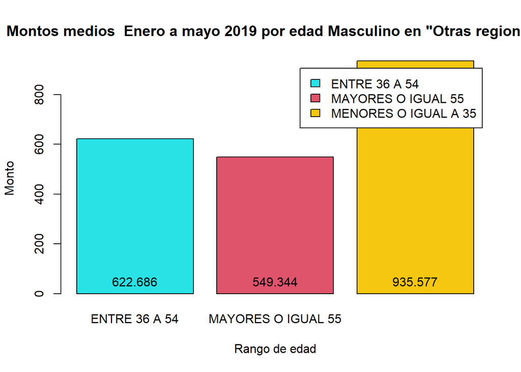

```r
hist_2 <-
  barplot(perfectiva_masculino$MontoAcum_mean,
          xlab="Rango de edad",
          legend.text=perfectiva_masculino$edad_n,
          col=c('5','2',55),
          main='Montos medios  Enero a mayo 2019 por edad Masculino en "Otras regiones"' ,
          ylab='Monto',

          names.arg=perfectiva_masculino$edad_n)

text(hist_1,
     0,
     round(perfectiva_masculino$MontoAcum_mean, 3),cex=1,pos=3)
```

La media se concentra menores y iguales 35 años con un 935.577.

### Media de los montos en Enero a mayo 2019 por edad Femenino en “Otras regiones”

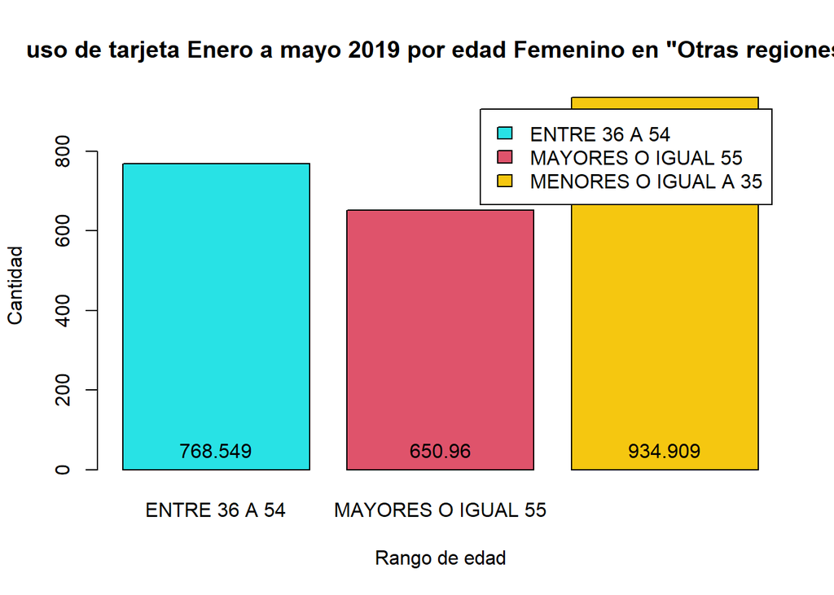

```r
#uso de tarjeta Uso2019 por edad segun la region
hist_1 <-
  barplot(perfectiva_femenino$MontoAcum_mean,
          xlab="Rango de edad",
          legend.text=perfectiva_femenino$edad_n,
          col=c('5','2',55),
          main='uso de tarjeta Enero a mayo 2019 por edad Femenino en "Otras regiones"' ,
          ylab='Cantidad',

          names.arg=perfectiva_femenino$edad_n)

text(hist_1,
     0,
     round(perfectiva_femenino$MontoAcum_mean, 3),cex=1,pos=3)
```

La media se concentra menores y iguales 35 años con un 934.909.

## Informacion de RM

```r
library(tidyverse)
#RM
# analisis  femenino  y masculino de otras RM

perfectiva_femenino2 <-
  datos %>%
  group_by( reg_n,edad_n,sex_n) %>%
  summarise(MontoAcum_mean  = mean(MontoAcum ),MontoMayo_mean  = mean(MontoMayo ),Uso2019  = sum(Uso2019 ),MontoAcum  = sum(MontoAcum ),UsoMayo  = sum(UsoMayo ),MontoMayo  = sum(MontoMayo ))  %>%
  filter( reg_n=="RM",sex_n =="Femenino" )
```

### resumen en tabla de la region metropolitana mujeres y sus rango de edad

```r
kableExtra::scroll_box(knitr::kable(head(perfectiva_femenino2)), height = 3, fixed_thead = list(enabled = T/F, background = "anycolor"))
```

| reg_n | edad_n | sex_n | MontoAcum_mean | MontoMayo_mean | Uso2019 | MontoAcum | UsoMayo | MontoMayo |
| --- | --- | --- | --- | --- | --- | --- | --- | --- |
| RM | ENTRE 36 A 54 | Femenino | 913.6250 | 212.0750 | 28 | 36545 | 20 | 8483 |
| RM | MAYORES O IGUAL 55 | Femenino | 212.0370 | 19.7037 | 6 | 5725 | 2 | 532 |
| RM | MENORES O IGUAL A 35 | Femenino | 997.0526 | 278.7895 | 15 | 18944 | 12 | 5297 |

```r
perfectiva_masculino2 <-
  datos %>%
  group_by( reg_n,edad_n,sex_n) %>%
  summarise(MontoAcum_mean  = mean(MontoAcum ),MontoMayo_mean  = mean(MontoMayo ),Uso2019  = sum(Uso2019 ),MontoAcum  = sum(MontoAcum ),UsoMayo  = sum(UsoMayo ),MontoMayo  = sum(MontoMayo ))  %>%
  filter( reg_n=="RM",sex_n =="Masculino" )
```

### resumen en tabla de la region metropolitana masculino y sus rango de edad

```r
kableExtra::scroll_box(knitr::kable(head(perfectiva_masculino2)), height = 3, fixed_thead = list(enabled = T/F, background = "anycolor"))
```

| reg_n | edad_n | sex_n | MontoAcum_mean | MontoMayo_mean | Uso2019 | MontoAcum | UsoMayo | MontoMayo |
| --- | --- | --- | --- | --- | --- | --- | --- | --- |
| RM | ENTRE 36 A 54 | Masculino | 887.2982 | 238.1930 | 39 | 50576 | 28 | 13577 |
| RM | MAYORES O IGUAL 55 | Masculino | 435.7083 | 115.3958 | 19 | 20914 | 13 | 5539 |
| RM | MENORES O IGUAL A 35 | Masculino | 744.3529 | 171.5294 | 13 | 12654 | 7 | 2916 |

### Uso en mayo en “RM” y Femenino

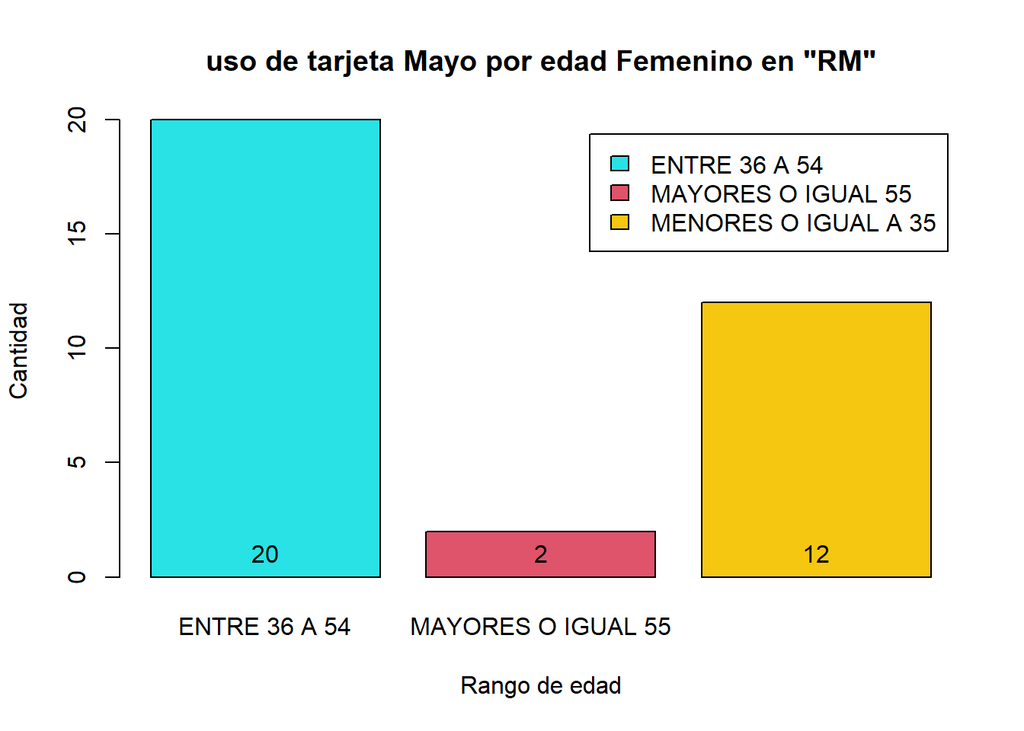

```r
#frecuencia
# uso de tarjeta UsoMayo por edad segun la region
hist_1 <-
barplot(perfectiva_femenino2$UsoMayo,
        xlab="Rango de edad",
legend.text=perfectiva_femenino2$edad_n,
col=c('5','2',55),
main='uso de tarjeta Mayo por edad Femenino en "RM"' ,
ylab='Cantidad',

names.arg=perfectiva_femenino2$edad_n)

text(hist_1,
0,
round(perfectiva_femenino2$UsoMayo, 3),cex=1,pos=3)
```

Tiene mayor cantidad de uso entre la edad de 36 a 54, 20 veces en mayo 2019.

### Uso en mayo en “RM” y Masculino

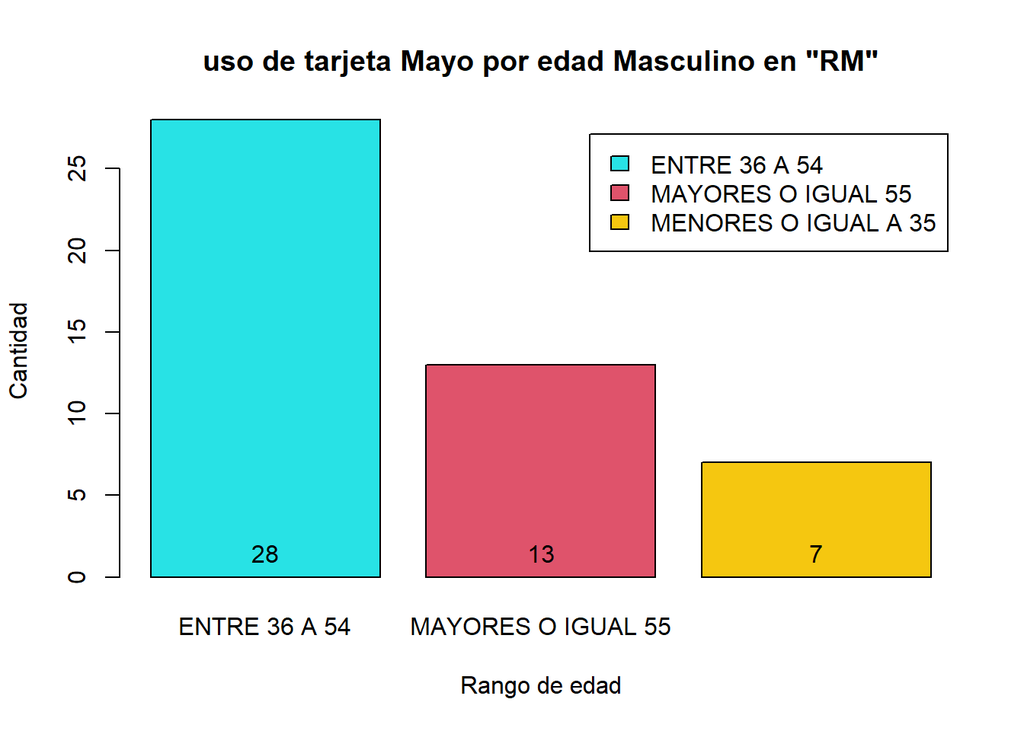

```r
hist_2 <-
barplot(perfectiva_masculino2$UsoMayo,
xlab="Rango de edad",
legend.text=perfectiva_masculino2$edad_n,
col=c('5','2',55),
          main='uso de tarjeta Mayo por edad Masculino en "RM"' ,
ylab='Cantidad',

names.arg=perfectiva_masculino2$edad_n)

text(hist_1,
0,
round(perfectiva_masculino2$UsoMayo, 3),cex=1,pos=3)
```

Tiene mayor cantidad de uso entre la edad de 36 a 54, 28 veces en mayo 2019.

### Uso de tarjeta Enero a mayo 2019 por edad Femenino en “RM”

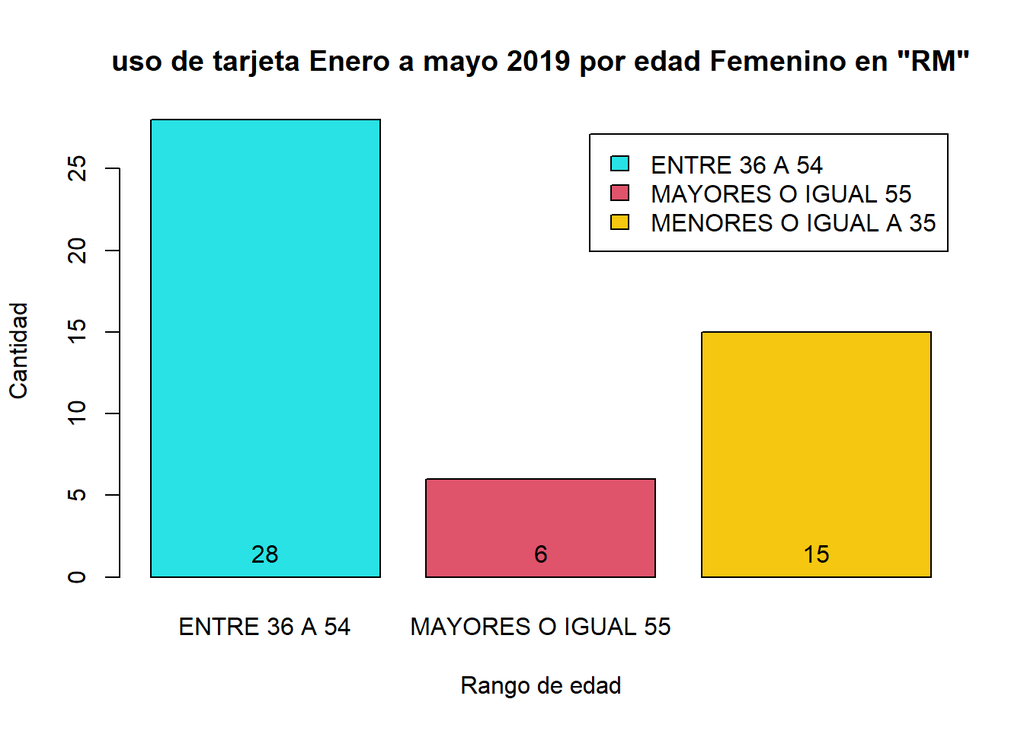

```r
#uso de tarjeta Uso2019 por edad segun la region
hist_1 <-
  barplot(perfectiva_femenino2$Uso2019,
          xlab="Rango de edad",
          legend.text=perfectiva_femenino2$edad_n,
          col=c('5','2',55),
          main='uso de tarjeta Enero a mayo 2019 por edad Femenino en "RM"' ,
          ylab='Cantidad',

          names.arg=perfectiva_femenino2$edad_n)

text(hist_1,
     0,
     round(perfectiva_femenino2$Uso2019, 3),cex=1,pos=3)
```

Tiene mayor cantidad de uso entre la edad de 36 a 54, 28 veces en enero a mayo 2019.

### Uso de tarjeta Enero a mayo 2019 por edad Masculino en “RM”

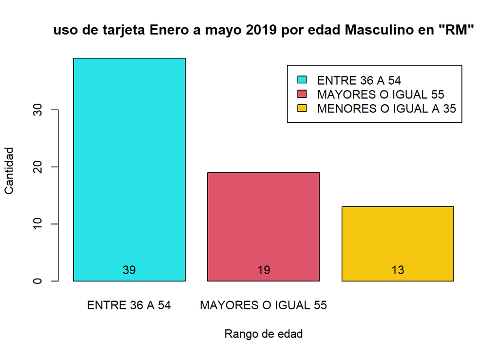

```r
hist_2 <-
  barplot(perfectiva_masculino2$Uso2019,
          xlab="Rango de edad",
          legend.text=perfectiva_masculino2$edad_n,
          col=c('5','2',55),
          main='uso de tarjeta Enero a mayo 2019 por edad Masculino en "RM"' ,
          ylab='Cantidad',

          names.arg=perfectiva_masculino2$edad_n)

text(hist_1,
     0,
     round(perfectiva_masculino2$Uso2019, 3),cex=1,pos=3)
```

Tiene mayor cantidad de uso entre la edad de 36 a 54, 39 veces en enero a mayo 2019.

### Media Monto en mayo en “RM” y Femenino

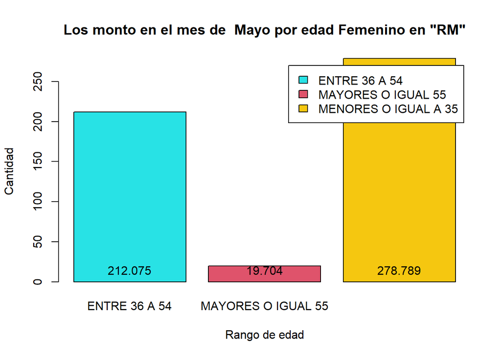

```r
#frecuencia
# uso de tarjeta UsoMayo por edad segun la region
hist_1 <-
barplot(perfectiva_femenino2$MontoMayo_mean,
        xlab="Rango de edad",
legend.text=perfectiva_femenino2$edad_n,
col=c('5','2',55),
main='Los monto en el mes de  Mayo por edad Femenino en "RM"' ,
ylab='Cantidad',

names.arg=perfectiva_femenino2$edad_n)

text(hist_1,
0,
round(perfectiva_femenino2$MontoMayo_mean, 3),cex=1,pos=3)
```

Tiene un mayor media de 278.789, para las menores io iguales de 35 años femeninas.

### Media Monto en mayo en “RM” y Masculino

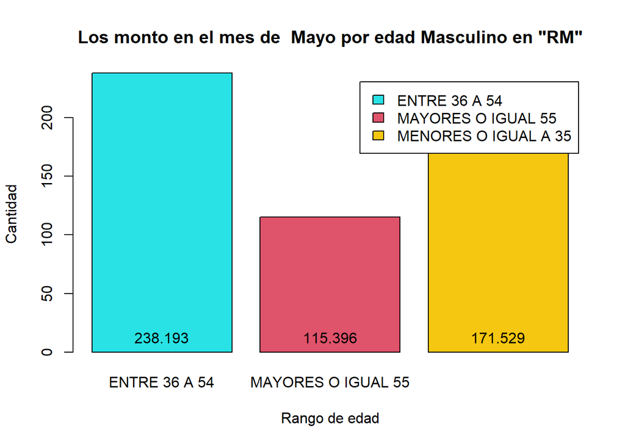

```r
#frecuencia
# uso de tarjeta UsoMayo por edad segun la region
hist_1 <-
barplot(perfectiva_masculino2$MontoMayo_mean,
        xlab="Rango de edad",
legend.text=perfectiva_masculino2$edad_n,
col=c('5','2',55),
main='Los monto en el mes de  Mayo por edad Masculino en "RM"' ,
ylab='Cantidad',

names.arg=perfectiva_masculino2$edad_n)

text(hist_1,
0,
round(perfectiva_masculino2$MontoMayo_mean, 3),cex=1,pos=3)
```

Tiene un mayor media de 238.193 entre las edades de 35 a 54,el genero masculino.

### Media de los montos en Enero a mayo 2019 por edad Masculino en “RM”

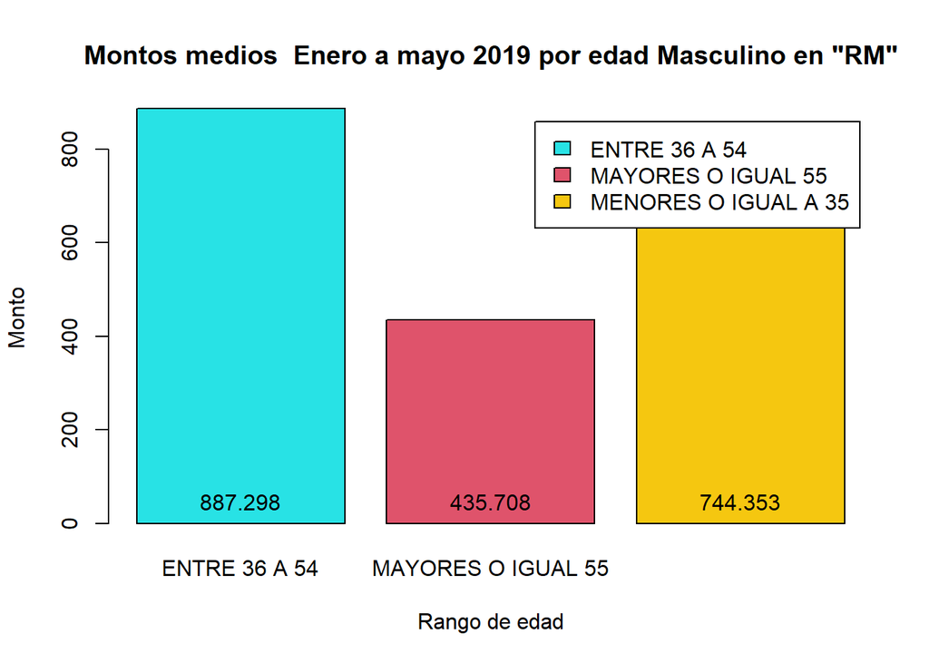

```r
hist_2 <-
  barplot(perfectiva_masculino2$MontoAcum_mean,
          xlab="Rango de edad",
          legend.text=perfectiva_masculino2$edad_n,
          col=c('5','2',55),
          main='Montos medios  Enero a mayo 2019 por edad Masculino en "RM"' ,
          ylab='Monto',

          names.arg=perfectiva_masculino2$edad_n)

text(hist_1,
     0,
     round(perfectiva_masculino2$MontoAcum_mean, 3),cex=1,pos=3)
```

La media de los montos acumulado entre enero y mayo 2019 es de 887.298 entre 36 a 54, de los generos masculinos.

### Media de los montos en Enero a mayo 2019 por edad Femenino en “RM”

[figure not shown]

```r
#uso de tarjeta Uso2019 por edad segun la region
hist_1 <-
  barplot(perfectiva_femenino2$MontoAcum_mean,
          xlab="Rango de edad",
          legend.text=perfectiva_femenino2$edad_n,
          col=c('5','2',55),
          main='uso de tarjeta Enero a mayo 2019 por edad Femenino en "Otras regiones"' ,
          ylab='Cantidad',

          names.arg=perfectiva_femenino2$edad_n)

text(hist_1,
     0,
     round(perfectiva_femenino2$MontoAcum_mean, 3),cex=1,pos=3)
```

La media de los montos acumulado entre enero y mayo 2019 se concentra menores y iguales 35 años con un 997.053